# A comparison of three-dimensional rotation formalisms for least-squares and Bayesian inverse kinematics

## Appendix B

Ben Serrien, Klevis Aliaj, Todd Pataky

In this appendix, we demonstrate the use of the **pybik** package for doing IK simulations. See the main paper for performance of the different methods and Appendix A for details on the mathematics and statistics. It requires the following packages to be installed: **numpy**, **scipy** and **pymc2**. The first two come pre-installed with python distributions like Anaconda. The last can be installed from the instructions given here: https://pymc-devs.github.io/pymc/. The **directional** module is translated to python from the R package Directional (https://cran.r-project.org/package=Directional) and can be found here: https://github.com/0todd0000/PyDirectional. The **pybik** package was developed and tested on the following system: Python 3.7.7 (Anaconda 1.9.12), Numpy 1.19.1, Scipy 1.5.2, PyMC 2.3.8. The Anaconda environment file can be found in the repository. It was tested on Linux, Mac and Windows.

## Set-up

Import the packages and set a seed for the RNG for replication purposes.

```python
import numpy as np
import pybik
np.random.seed( 1 )
```

We set up the intial marker positions with known coordinates. In this example, we use a square marker cluster of 100$\times$100 mm² located at a distance of 50 mm from the origin. The marker coordinates are entered in a MarkerCluster object `r0`.

```python
r0 = np.array([[100.,0.,50.],[-100.,0.,50.],[0.,100.,50.],[0.,-100.,50.]])
r0 = pybik.MarkerCluster( r0 )
```

We simulate a random rotation `r` that we treat as the 'true' rotation. We only specify the rotation magnitude `theta`, the rotation direction is random. The final coordinates `r1` are then calculated by applying the rotation to the initial coordinates.

```python
theta = np.radians(45)                                 # rotation magnitude
r     = pybik.random.rotation3( theta )                # rotation object
r1    = pybik.MarkerCluster( r.apply( r0.toarray() ) ) # final coordinates
```

Here we print the different $SO(3)$ representations of the true rotation (for comparison with estimated rotations):

```python
print('quaternion: ',        r.as_quat(), sep = '\n')
print('rotation matrix: ',   r.as_matrix(), sep = '\n')
print('rotation vector: ',   r.as_rotvec(), sep = '\n')
print('YXY Euler angles: ',  r.as_euler('YXY'), sep = '\n')
print('ZXY Cardan angles: ', r.as_euler('ZXY'), sep = '\n')
```

```
quaternion:
[[ 0.382394   -0.00524476 -0.01392597  0.92387953]]
rotation matrix:
[[[ 9.99557120e-01  2.17207052e-02 -2.03414649e-02]
  [-2.97429631e-02  7.07161796e-01 -7.06425899e-01]
  [-9.59361866e-04  7.06718052e-01  7.07494646e-01]]]
rotation vector:
[[ 0.78480414 -0.01076405 -0.02858088]]
YXY Euler angles:
[[ 0.03072494  0.78532036 -0.04207859]]
ZXY Cardan angles:
[[-0.03070567  0.78484857  0.001356  ]]
```

Now we add i.i.d. uncorrelated and isotropic Gaussian noise with standard deviation `sigma` to the true marker coordinates. The noisy "measured" coordinates (`r0n, r1n`) are used for IK.

```python
sigma = 2.  # SD of the noise (in mm)
r0n   = r0.add_noise(sigma)
r1n   = r1.add_noise(sigma)
```

The noisy marker coordinates are entered in a IK mechanism object. The true value of `sigma` is entered as well which is used for initiating the MCMC algorithm in BIK.

```python
model = pybik.mechanisms.rotation3(r0n, r1n, sigma)
```

## IK solutions

Below we conduct the different IK methods and print the solutions in the different $SO(3)$ representations. An overview of the estimation errors is presented afterwards.

**Singular Value Decomposition**

```python
r_svd = model.ik_svd()
print('quaternion: ',        r_svd.as_quat(), sep = '\n')
print('rotation matrix: ',   r_svd.as_matrix(), sep = '\n')
print('rotation vector: ',   r_svd.as_rotvec(), sep = '\n')
print('YXY Euler angles: ',  r_svd.as_euler('YXY'), sep = '\n')
print('ZXY Cardan angles: ', r_svd.as_euler('ZXY'), sep = '\n')
```

```
quaternion:
[ 0.38443476 -0.02355459 -0.02562438  0.92249579]
rotation matrix:
[[ 0.99757714  0.02916637 -0.06315982]
 [-0.06538717  0.70310662 -0.70807175]
 [ 0.02375621  0.71048604  0.7033102 ]]
rotation vector:
[ 0.78937004 -0.04836525 -0.05261522]
YXY Euler angles:
[ 0.04102825  0.79103937 -0.09208424]
ZXY Cardan angles:
[-0.04145837  0.79018865 -0.03376487]
```

**Quaternion-based LS**

```python
r_lsquat = model.ik_ls_quat()
print('quaternion: ',        r_svd.as_quat(), sep = '\n')
print('rotation matrix: ',   r_svd.as_matrix(), sep = '\n')
print('rotation vector: ',   r_svd.as_rotvec(), sep = '\n')
print('YXY Euler angles: ',  r_svd.as_euler('YXY'), sep = '\n')
print('ZXY Cardan angles: ', r_svd.as_euler('ZXY'), sep = '\n')
```

```
quaternion:
[ 0.38443476 -0.02355459 -0.02562438  0.92249579]
rotation matrix:
[[ 0.99757714  0.02916637 -0.06315982]
 [-0.06538717  0.70310662 -0.70807175]
 [ 0.02375621  0.71048604  0.7033102 ]]
rotation vector:
[ 0.78937004 -0.04836525 -0.05261522]
YXY Euler angles:
[ 0.04102825  0.79103937 -0.09208424]
ZXY Cardan angles:
[-0.04145837  0.79018865 -0.03376487]
```

**Non-Linear Least-Squares**

```python
r_nlls = model.ik_nlls()
print('quaternion: ',        r_nlls.as_quat(), sep = '\n')
print('rotation matrix: ',   r_nlls.as_matrix(), sep = '\n')
print('rotation vector: ',   r_nlls.as_rotvec(), sep = '\n')
print('YXY Euler angles: ',  r_nlls.as_euler('YXY'), sep = '\n')
print('ZXY Cardan angles: ', r_nlls.as_euler('ZXY'), sep = '\n')
```

```
quaternion:
[ 0.38199973 -0.01156984 -0.02070702  0.92385798]
rotation matrix:
[[ 0.99887472  0.02942134 -0.03719793]
 [-0.04710004  0.70729485 -0.70534784]
 [ 0.00555763  0.70630615  0.70788469]]
rotation vector:
[ 0.78400081 -0.02374548 -0.04249825]
YXY Euler angles:
[ 0.04163115  0.78513215 -0.06667664]
ZXY Cardan angles:
[-0.04157303  0.78426654 -0.00785088]
```

**Variational Bayesian IK**

```python
r_vbik = model.ik_vb()
print('quaternion: ',        r_vbik.as_quat(), sep = '\n')
print('rotation matrix: ',   r_vbik.as_matrix(), sep = '\n')
print('rotation vector: ',   r_vbik.as_rotvec(), sep = '\n')
print('YXY Euler angles: ',  r_vbik.as_euler('YXY'), sep = '\n')
print('ZXY Cardan angles: ', r_vbik.as_euler('ZXY'), sep = '\n')
```

```
quaternion:
[ 0.38200087 -0.01189242 -0.02083955  0.92385043]
rotation matrix:
[[ 0.99884857  0.02941943 -0.03789509]
 [-0.04759109  0.70728209 -0.70532767]
 [ 0.00605218  0.70631901  0.70786781]]
rotation vector:
[ 0.7840052  -0.02440759 -0.04277037]
YXY Euler angles:
[ 0.0416277   0.7851502  -0.06737162]
ZXY Cardan angles:
[-0.04157109  0.7842847  -0.00854966]
```

```
/home/ben/Documenten/Bayesian IK/PYTHON/pybik/vbik.py:23: RuntimeWarning: divide by zero encountered in log
  logdetX = 2 * np.trace(log( cholesky(X) ))
/home/ben/Documenten/Bayesian IK/PYTHON/pybik/vbik.py:23: RuntimeWarning: invalid value encountered in log
  logdetX = 2 * np.trace(log( cholesky(X) ))
```

The warnings arrise because the determinant of the precision matrix of the normal prior on the quaternion is very small at initialization of the VBIK EM-algorithm.

**BIK (rotation vector, 1st option)** (alternative rotation vector model not reported in the manuscript)

```python
r_bik1, sigma_bik1 = model.ik_bik_axang1()
print('', 'quaternion: ',    r_bik1.as_quat(), sep = '\n')
print('rotation matrix: ',   r_bik1.as_matrix(), sep = '\n')
print('rotation vector: ',   r_bik1.as_rotvec(), sep = '\n')
print('YXY Euler angles: ',  r_bik1.as_euler('YXY'), sep = '\n')
print('ZXY Cardan angles: ', r_bik1.as_euler('ZXY'), sep = '\n')
```

```
 [-----------------100%-----------------] 150000 of 150000 complete in 32.0 sec
quaternion:
[ 0.38146622 -0.01200622 -0.02081591  0.92407038]
rotation matrix:
[[ 0.9988451   0.0293108  -0.03807031]
 [-0.04763066  0.70810045 -0.70450343]
 [ 0.00630804  0.70550311  0.70867875]]
rotation vector:
[ 0.78284838 -0.02463926 -0.04271859]
YXY Euler angles:
[ 0.04152207  0.78399192 -0.06750611]
ZXY Cardan angles:
[-0.04136994  0.78313279 -0.0089009 ]
```

**BIK (rotation vector, 2nd option)** (reported in the manuscript)

```python
r_bik2, sigma_bik2 = model.ik_bik_axang2()
print('','quaternion: ',     r_bik2.as_quat(), sep = '\n')
print('rotation matrix: ',   r_bik2.as_matrix(), sep = '\n')
print('rotation vector: ',   r_bik2.as_rotvec(), sep = '\n')
print('YXY Euler angles: ',  r_bik2.as_euler('YXY'), sep = '\n')
print('ZXY Cardan angles: ', r_bik2.as_euler('ZXY'), sep = '\n')
```

```
 [-----------------100%-----------------] 150000 of 150000 complete in 30.6 sec
quaternion:
[ 0.38180712 -0.01180388 -0.020681    0.92393522]
rotation matrix:
[[ 0.99886593  0.0292022  -0.03760434]
 [-0.04722942  0.70759124 -0.70504185]
 [ 0.00601973  0.70601832  0.70816799]]
rotation vector:
[ 0.78358458 -0.02422515 -0.04244372]
YXY Euler angles:
[ 0.04133826  0.7847128  -0.06688818]
ZXY Cardan angles:
[-0.04124647  0.78386002 -0.00850022]
```

**BIK (intrinsic Euler YXY sequence)**

```python
r_bik3, sigma_bik3 = model.ik_bik_eulYXY()
print('','quaternion: ',     r_bik3.as_quat(), sep = '\n')
print('rotation matrix: ',   r_bik3.as_matrix(), sep = '\n')
print('rotation vector: ',   r_bik3.as_rotvec(), sep = '\n')
print('YXY Euler angles: ',  r_bik3.as_euler('YXY'), sep = '\n')
print('ZXY Cardan angles: ', r_bik3.as_euler('ZXY'), sep = '\n')
```

```
 [-----------------100%-----------------] 150000 of 150000 complete in 46.0 sec
quaternion:
[ 0.38190678 -0.01217182 -0.02064651  0.92389002]
rotation matrix:
[[ 0.99885114  0.02885321 -0.03826092]
 [-0.0474472   0.70744186 -0.70517712]
 [ 0.00672076  0.70618235  0.70799811]]
rotation vector:
[ 0.78380137 -0.02498067 -0.04237359]
YXY Euler angles:
[ 0.0408353   0.78492418 -0.06718283]
ZXY Cardan angles:
[-0.04076268  0.78409167 -0.00949234]
```

**BIK (intrinsic Cardan ZXY sequence)**

```python
r_bik4, sigma_bik4 = model.ik_bik_eulZXY()
print('','quaternion: ',     r_bik4.as_quat(), sep = '\n')
print('rotation matrix: ',   r_bik4.as_matrix(), sep = '\n')
print('rotation vector: ',   r_bik4.as_rotvec(), sep = '\n')
print('YXY Euler angles: ',  r_bik4.as_euler('YXY'), sep = '\n')
print('ZXY Cardan angles: ', r_bik4.as_euler('ZXY'), sep = '\n')
```

```
 [-----------------100%-----------------] 150000 of 150000 complete in 50.4 sec
quaternion:
[ 0.38209342 -0.0115504  -0.02062139  0.92382139]
rotation matrix:
[[ 0.99888269  0.0292743  -0.03709962]
 [-0.04692763  0.70715875 -0.70549578]
 [ 0.00558242  0.70644852  0.70774241]]
rotation vector:
[ 0.78420301 -0.02370588 -0.04232305]
YXY Euler angles:
[ 0.041415    0.78532466 -0.0664194 ]
ZXY Cardan angles:
[-0.04137345  0.78446768 -0.00788748]
```

**BIK (quaternion, 1st option)** (alternative quaternion model not reported in the manuscript)

```python
r_bik5, sigma_bik5 = model.ik_bik_quat1()
print('','quaternion: ',     r_bik5.as_quat(), sep = '\n')
print('rotation matrix: ',   r_bik5.as_matrix(), sep = '\n')
print('rotation vector: ',   r_bik5.as_rotvec(), sep = '\n')
print('YXY Euler angles: ',  r_bik5.as_euler('YXY'), sep = '\n')
print('ZXY Cardan angles: ', r_bik5.as_euler('ZXY'), sep = '\n')
```

```
 [-----------------100%-----------------] 150000 of 150000 complete in 34.3 sec
quaternion:
[-0.38173871  0.00848856  0.01564905 -0.92409881]
rotation matrix:
[[ 0.9993661   0.02244171 -0.02763624]
 [-0.03540337  0.70806133 -0.70526289]
 [ 0.00374085  0.70579424  0.70840701]]
rotation vector:
[ 0.78339989 -0.01742014 -0.03211481]
YXY Euler angles:
[ 0.03178568  0.78404731 -0.05015672]
ZXY Cardan angles:
[-0.03168398  0.78354367 -0.0052806 ]
```

**BIK (quaternion, 2nd option)** (reported in the manuscript)

```python
r_bik6, sigma_bik6 = model.ik_bik_quat2()
print('','quaternion: ',     r_bik6.as_quat(), sep = '\n')
print('rotation matrix: ',   r_bik6.as_matrix(), sep = '\n')
print('rotation vector: ',   r_bik6.as_rotvec(), sep = '\n')
print('YXY Euler angles: ',  r_bik6.as_euler('YXY'), sep = '\n')
print('ZXY Cardan angles: ', r_bik6.as_euler('ZXY'), sep = '\n')
```

```
 [-----------------100%-----------------] 150000 of 150000 complete in 27.9 sec
quaternion:
[ 0.38195179 -0.01184947 -0.01944129  0.92390176]
rotation matrix:
[[ 0.99896325  0.02687183 -0.03674677]
 [-0.04497554  0.70746973 -0.70531112]
 [ 0.00704422  0.7062326   0.70794484]]
rotation vector:
[ 0.78389056 -0.02431901 -0.03989992]
YXY Euler angles:
[ 0.03803121  0.78488474 -0.06368073]
ZXY Cardan angles:
[-0.03796477  0.78416265 -0.00994991]
```

## Estimation errors

The metric(6) from Huynh (2009) is used to compare the relative accuracy of the different IK methods.

```python
err_svd    = r_svd * r.inv()
err_lsquat = r_lsquat * r.inv()
err_nlls   = r_nlls * r.inv()
err_vbik   = r_vbik * r.inv()
err_bik1   = r_bik1 * r.inv()
err_bik2   = r_bik2 * r.inv()
err_bik3   = r_bik3 * r.inv()
err_bik4   = r_bik4 * r.inv()
err_bik5   = r_bik5 * r.inv()
err_bik6   = r_bik6 * r.inv()

print('error SVD (deg)   :' , err_svd.magnitude()*(180/np.pi) )
print('error lsQUAT (deg):' , err_lsquat.magnitude()*(180/np.pi) )
print('error NLLS (deg)  :' , err_nlls.magnitude()*(180/np.pi) )
print('error VBIK (deg)  :' , err_vbik.magnitude()*(180/np.pi) )
print('error BIK_1 (deg) :' , err_bik1.magnitude()*(180/np.pi) )
print('error BIK_2 (deg) :' , err_bik2.magnitude()*(180/np.pi) )
print('error BIK_3 (deg) :' , err_bik3.magnitude()*(180/np.pi) )
print('error BIK_4 (deg) :' , err_bik4.magnitude()*(180/np.pi) )
print('error BIK_5 (deg) :' , err_bik5.magnitude()*(180/np.pi) )
print('error BIK_6 (deg) :' , err_bik6.magnitude()*(180/np.pi) )
```

```
error SVD (deg)   : [2.50586652]
error lsQUAT (deg): [2.50586652]
error NLLS (deg)  : [1.06357922]
error VBIK (deg)  : [1.09999041]
error BIK_1 (deg) : [1.1115173]
error BIK_2 (deg) : [1.0810587]
error BIK_3 (deg) : [1.10738374]
error BIK_4 (deg) : [1.05451746]
error BIK_5 (deg) : [0.42828422]
error BIK_6 (deg) : [0.98733461]
```

For this example, BIK with the quaternion representation (BIK_5 and BIK_6) is the most accurate. The SVD and lsQUAT estimates are the least accurate.

In the simultation experiment, we repeat this process 1000 times to calculate the relative performance of the models.

### Why the (absolute) difference between between $SO(3)$ parameterizations is not a proper metric for the estimation error?

Comparing the different IK solutions above to the true rotation, it is clear that the (absolute) difference between the true and estimated representations, is not a good error metric. For example, we print here the rotation vector representation of the true rotation, estimated rotation, error rotation, and difference between the true and estimated rotation. The latter two do not match in sign and magnitude. This is shown in the figure below (arrowheads don't touch). The metric from Huynh (2009) calculates the smallest angle between the rotation vectors and is always a proper metric.

```python
print('true', r.as_rotvec(), sep = '\n')
print('SVD estimate', r_svd.as_rotvec(), sep = '\n')
print('error', err_svd.as_rotvec(), sep = '\n')
print('absolute difference', r.as_rotvec() - r_svd.as_rotvec(), sep = '\n')
```

```
true
[[ 0.78480414 -0.01076405 -0.02858088]]
SVD estimate
[ 0.78937004 -0.04836525 -0.05261522]
error
[[ 0.0044422  -0.02495869 -0.03563896]]
absolute difference
[[-0.0045659   0.0376012   0.02403434]]
```

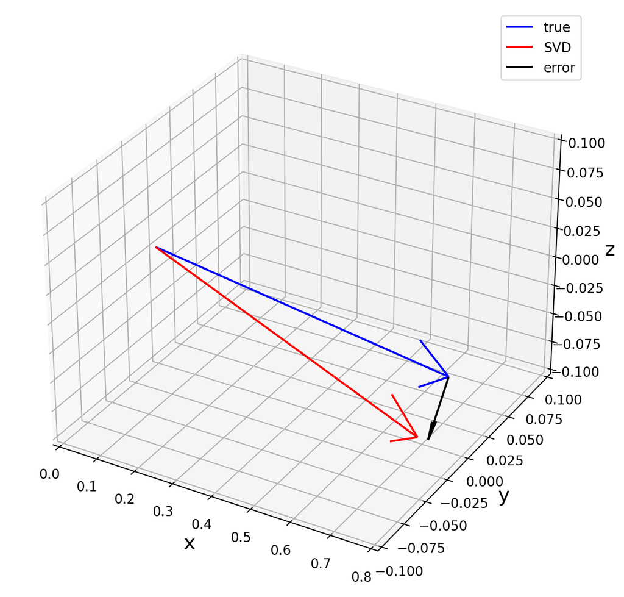

```python
from matplotlib import pyplot as plt
from mpl_toolkits.mplot3d import Axes3D
%matplotlib inline

rt = r.as_rotvec()       # true
rh = r_svd.as_rotvec()   # estimate
re = err_svd.as_rotvec() # error

fig = plt.figure(figsize = (12,8), dpi = 200)
ax  = fig.add_subplot(111, projection = '3d')
ax.set_xlim(0,.8)
ax.set_ylim(-.1,.1)
ax.set_zlim(-.1,.1)
ax.quiver(0,0,0,rt[0,0],rt[0,1],rt[0,2], color = 'blue', label = 'true', arrow_length_ratio = 0.1)
ax.quiver(0,0,0,rh[0],rh[1],rh[2], color = 'red', label = 'SVD', arrow_length_ratio = 0.1)
ax.quiver(rt[0,0],rt[0,1],rt[0,2], re[0,0],re[0,1],re[0,2], color = 'black', label = 'error')
ax.set_xlabel('x', fontsize = 15)
ax.set_ylabel('y', fontsize = 15)
ax.set_zlabel('z', fontsize = 15)
ax.legend()
```

The same applies to the other representations.

```python
print('true', r.as_euler('YXY', degrees = True), sep = '\n')
print('SVD estimate', r_svd.as_euler('YXY', degrees = True), sep = '\n')
print('error', err_svd.as_euler('YXY', degrees = True), sep = '\n')
```

```
true
[[ 1.7604094  44.99554205 -2.41092569]]
SVD estimate
[ 2.3507456  45.32321732 -5.27603851]
error
[[ 82.17994804   2.05770966 -83.61012909]]
```

```python
print('true', r.as_euler('ZXY', degrees = True), sep = '\n')
print('SVD estimate', r_svd.as_euler('ZXY', degrees = True), sep = '\n')
print('error', err_svd.as_euler('ZXY', degrees = True), sep = '\n')
```

```
true
[[-1.75930543 44.96851052  0.07769296]]
SVD estimate
[-2.37538963 45.27447447 -1.93458463]
error
[[-2.03858977  0.27991764 -1.42520077]]
```

```python
print('true', r.as_quat(), sep = '\n')
print('SVD estimate', r_svd.as_quat(), sep = '\n')
print('error', err_svd.as_quat(), sep = '\n')
```

```
true
[[ 0.382394   -0.00524476 -0.01392597  0.92387953]]
SVD estimate
[ 0.38443476 -0.02355459 -0.02562438  0.92249579]
error
[[-0.00222092  0.01247835  0.01781806 -0.99976091]]
```